# Round 2: DAZONE

Hoang-Chau Luong

06/06/2022

```r
library(tidyverse)
library(tidymodels)
library(lubridate)

theme_set(theme_light())
```

# 1 **Import data**

```r
front_end <- read_csv("data_round_2/Front-end dataset.csv") %>%
  mutate(date = as.POSIXct(timestamp/1e3, origin = "1970-01-01", tz = "GMT")) %>%
  select(-6, -7)

back_end <- read_csv("data_round_2/Back-end dataset.csv") %>%
  mutate(date = as.POSIXct(timestamp/1e3, origin = "1970-01-01", tz = "GMT"))

meta_data <- read_csv("data_round_2/Meta dataset.csv") %>%
  mutate(date = as.POSIXct(timeStampHash/1e3, origin = "1970-01-01", tz = "GMT"))

names(front_end)
```

```
## [1] "eventid"   "id"        "screenid"  "timestamp" "date"
```

```r
names(back_end)
```

```
## [1] "timestamp"  "stepresult" "id"         "date"
```

# 2 **Some analysis & Compared**

## 2.1 **How many userid ?**

We have **13369** unique **id** in `front_end`. And compare to `back_end` only has **3950** unique userid. The `back_end` dataset record whenever user click `"Lien ket ngay"`

So, **9419** user only interact on UI and don’t click to `"Lien ket ngay"`.

```r
front_end %>%
  count(id, sort = TRUE) %>%
  dim()
```

```
## [1] 13369     2
```

```r
back_end %>%
  count(id, sort = TRUE) %>%
  dim()
```

```
## [1] 3950    2
```

## 2.2 **Add type column**

- From the definition of new and old user that user using multiple screen like 12, 13, … is new user and otherwise is old user.
- So, I add new column `type` (“old” or “new”) represent for this attribute.

Following step:

- First, I extract the users belong to `new type` by filter all row dot not have `screenid 11` and then add type `new` for all users in this relation.
- Second, from first step I have a list of new user, then I join this list with `front_end` dataset and add type `old` for all users do not have type value.

End up having two new relation: * First is `user_type` containing unique `id` and their type, * Second is `front_end_ui` that is similar to `front_end` except have new column `type`.

```r
new_user <- front_end %>%
  select(id, screenid) %>%
  unique() %>%
  filter(screenid != 11) %>%
  group_by(id) %>%
  summarise(type = "new") %>%
  ungroup()

front_end_ui <- front_end %>%
  left_join(new_user, by = "id") %>%
  mutate(type = ifelse(is.na(type), "old", type))

user_type <- front_end_ui %>%
  group_by(id, type) %>%
  summarize(n = n()) %>%
  select(-n) %>%
  ungroup()
```

## 2.3 **Count number new user and old user**

```r
front_end_ui %>%
  group_by(id, type) %>%
  summarize(n = n(),
            retry = ifelse(n > 1, 1, 0)) %>%
  ungroup() %>%
  group_by(type) %>%
  summarize(n_ = n()) %>%
  gt::gt()
```

| type | n_ |
| --- | --- |
| new | 1279 |
| old | 12090 |

```r
# front_end_ui %>%
#   group_by(id, type) %>%
#   summarize(n = n(),
#             retry = ifelse(n > 1, 1, 0)) %>%
#   ungroup() %>%
#   group_by(type, retry) %>%
#   summarize(n_ = n())
```

## 2.4 **Count retry based on ID**

- The approach for this query is consider one user is `retry` or `not` by adding the label `retry` to each ID appear at least 2 times in `back_end` dataset and otherwise for each ID appear at least 1 time in `back_end`.

```r
back_end %>%
  left_join(user_type, by = "id") %>%
  filter(!is.na(type)) %>%
  group_by(id, type) %>%
  summarize(n = n()) %>%
  ungroup() %>%
  group_by(type) %>%
  summarize(retry = sum(n!=1),
            no_retry = sum(n==1)) %>%
  gt::gt()
```

| type | retry | no_retry |
| --- | --- | --- |
| new | 255 | 220 |
| old | 1205 | 1135 |

## 2.5 **Missing id in front end dataset**

```r
back_end %>%
  left_join(user_type, by = "id") %>%
  filter(is.na(type)) %>%
  dim()
```

```
## [1] 1637    5
```

## 2.6 **User have status B in backend**

Noting that the result in this chunk code is computing `retry based on id`.

- Fisrt, I list all users have status `B` at least 1 time.

And we can see that **36/857** have status `B` more than 1 time.

```r
back_end %>%
  filter(stepresult == "B") %>%
  group_by(id, stepresult) %>%
  summarise(n = n()) %>%
  arrange(desc(n)) %>%
  head(10)
```

```
## # A tibble: 10 x 3
## # Groups:   id [10]
##    id                  stepresult     n
##    <chr>               <chr>      <int>
##  1 BFGJIEBGIJCAHCBEBEG B              6
##  2 ICJIFIEHJBJGHEEADCD B              6
##  3 HDADFGAAADCACECHIII B              4
##  4 BEGBDCECFGDEGFHJIDF B              3
##  5 BFDEIJDGFDCJDJFBJBD B              3
##  6 CJJBIFGHBAIBJGJGBG  B              3
##  7 GGFHICCGBFDCJCIBDEA B              3
##  8 IDJIEDHFEHGHACIJGEJ B              3
##  9 BJCBJIAIJBEHDGBEJJB B              2
## 10 BJGAAJFBDEBCIADJDBC B              2
```

- Second, I list all user have status B only 1 time **821** records.

This result is reveal that all user starting at screen 11, and when failing in this screen the new user is transfer to new UI, otherwise still stayed at screen 11.

- So the `no_retry` for this case who have `B` status exactly 1 time is value of `0`. Because for new user they must retry at least 1 time to access the new UI.

```r
user_one_B <- back_end %>%
  filter(stepresult == "B") %>%
  group_by(id, stepresult) %>%
  summarise(n = n()) %>%
  arrange(desc(n)) %>%
  filter(n == 1)

back_end %>%
  inner_join(user_one_B, by = "id") %>%
  left_join(user_type, by = "id") %>%
  filter(!is.na(type)) %>%
  group_by(id, type) %>%
  summarize(n = n()) %>%
  ungroup() %>%
  group_by(type) %>%
  summarize(retry = sum(n!=1),
            no_retry = sum(n==1)) %>%
  gt::gt()
```

| type | retry | no_retry |
| --- | --- | --- |
| new | 55 | 0 |
| old | 349 | 198 |

## 2.7 **Count retry based on sequence 00 and 01, no retry on sequence 0NULL**

- Total **retry** rate in `back_end` that meaning the number of times appear `00` and `01` in dataset `back_end`

```r
# total retry rate
back_end %>%
  mutate(encode = ifelse(stepresult == "B", 1, 0)) %>%
  group_by(id) %>%
  mutate(next_code = lead(encode, order_by = id)) %>%
  ungroup() %>%
  filter(!is.na(next_code)) %>%
  summarize(retry_rate = sum(encode == 0 & next_code == 0) + sum(encode == 0 & next_code == 1)) %>%
  gt::gt()
```

| retry_rate |
| --- |
| 3520 |

- **Retry** rate over `type` of user, this result lost some `id` compare to above result because some `id` in `back_end` do not appear in `front_end`.

```r
# retry rate over type
back_end %>%
  mutate(encode = ifelse(stepresult == "B", 1, 0)) %>%
  group_by(id) %>%
  mutate(next_code = lead(encode, order_by = id)) %>%
  ungroup() %>%
  filter(!is.na(next_code)) %>%
  inner_join(user_type, by = "id") %>%
  group_by(type) %>%
  summarize(retry_rate = sum(encode == 0 & next_code == 0) + sum(encode == 0 & next_code == 1)) %>%
  gt::gt()
```

| type | retry_rate |
| --- | --- |
| new | 567 |
| old | 2455 |

- Total **no_retry** rate in `back_end` that meaning the number of times appear `0NULL` in dataset `back_end`.

```r
# no retry rate
back_end %>%
  mutate(encode = ifelse(stepresult == "B", 1, 0)) %>%
  group_by(id) %>%
  mutate(next_code = lead(encode, order_by = id)) %>%
  ungroup() %>%
  summarize(no_retry = sum(encode == 0 & is.na(next_code))) %>%
  gt::gt()
```

| no_retry |
| --- |
| 3111 |

- **No_retry** rate over `type` of user, this result lost some `id` compare to above result because some `id` in `back_end` do not appear in `front_end`.

```r
# no retry rate over type
back_end %>%
  mutate(encode = ifelse(stepresult == "B", 1, 0)) %>%
  group_by(id) %>%
  mutate(next_code = lead(encode, order_by = id)) %>%
  ungroup() %>%
  inner_join(user_type, by = "id") %>%
  group_by(type) %>%
  summarize(no_retry = sum(encode == 0 & is.na(next_code))) %>%
  gt::gt()
```

| type | no_retry |
| --- | --- |
| new | 420 |
| old | 1775 |

## 2.8 **Hypotheses Testing for 2.7**

```r
matrx <- matrix(c(420, 1775, 567, 2455), ncol = 2, byrow = TRUE)
colnames(matrx) <- c("new", "old")
rownames(matrx) <- c("no_retry", "retry")
matrx
```

```
##          new  old
## no_retry 420 1775
## retry    567 2455
```

```r
n1 <- 567+420
n2 <- 2455+1775
p1_hat <- 567/(567+420)
p2_hat <- 2455/(2455+1775)

p_hat <- (n1*p1_hat + n2*p2_hat)/(n1+n2)

z_obs <- (p1_hat-p2_hat)/sqrt(p_hat*(1-p_hat)*(1/n1 + 1/n2))

# z_obs - qnorm(0.05)

pnorm(z_obs)
```

```
## [1] 0.3674299
```

- With **p value = 0.37 > 0.05**, we can not reject the null hypotheses that **p1 = p2**
- That means the ratio of retry in the new UI is **no difference** to the old UI

## 2.9 **Q3. Distribution of requests by the error**

### 2.9.1 **With id who have B status**

We have **908** status B for **857** unique ID

```r
back_end %>%
  filter(stepresult == "B")
```

```
## # A tibble: 908 x 4
##        timestamp stepresult id                  date
##            <dbl> <chr>      <chr>               <dttm>
##  1 1615860000000 B          HAAICIFCAIAAGBIJEGE 2021-03-16 02:00:00
##  2 1615890000000 B          CJBGECEFGDEIAJIGIJE 2021-03-16 10:20:00
##  3 1615890000000 B          CJBGECEFGDEIAJIGIJE 2021-03-16 10:20:00
##  4 1615810000000 B          HGFEBEFGHIIHDEGFDBD 2021-03-15 12:06:40
##  5 1615830000000 B          IJBAIIGEHGDHDCHGJAC 2021-03-15 17:40:00
##  6 1615880000000 B          JHAHJGIGAFBDDEHDACD 2021-03-16 07:33:20
##  7 1615860000000 B          IJBFBBBGFBHBHFGGDDE 2021-03-16 02:00:00
##  8 1615750000000 B          IHJFFJDBDCJBIHFHGFD 2021-03-14 19:26:40
##  9 1615740000000 B          JJFFFCCCDJGFBEAEACC 2021-03-14 16:40:00
## 10 1615870000000 B          BEEDAACIFDHBGDJFAFE 2021-03-16 04:46:40
## # ... with 898 more rows
```

- And then we add a `type` for each user
- New has **61** times status B.
- Old has **624** times status B.

```r
back_end %>%
  filter(stepresult == "B") %>%
  inner_join(user_type, by = "id") %>%
  group_by(type) %>%
  summarise(n = n()) %>%
  gt::gt()
```

| type | n |
| --- | --- |
| new | 61 |
| old | 624 |

### 2.9.2 **With id who have other status**

We have **6631** status differ B for **3615** unique ID.

```r
back_end %>%
  filter(stepresult != "B") %>%
  inner_join(user_type, by = "id") %>%
  group_by(type) %>%
  summarise(n = n()) %>%
  gt::gt()
```

| type | n |
| --- | --- |
| new | 987 |
| old | 4230 |

And then we add a `type` for each user

- New has **987** times differ status B.
- Old has **4230** times differ status B.

### 2.9.3 **Overall**

```r
back_end %>%
  inner_join(user_type, by = "id") %>%
  count(stepresult, type)
```

```
## # A tibble: 4 x 3
##   stepresult type      n
##   <chr>      <chr> <int>
## 1 #NAME?     new     987
## 2 #NAME?     old    4230
## 3 B          new      61
## 4 B          old     624
```

### 2.9.4 **Q3. Hypotheses Testing for error rate**

*NULL Hypotheses: $H_0: p1 = p2$.

*Alternative Hypotheses: $H_1: p1 > p2$.

```r
n1 <- 61+987
n2 <- 624+4230
p1_hat <- 987/n1
p2_hat <- 4230/n2

p_hat <- (n1*p1_hat + n2*p2_hat)/(n1+n2)

z_obs <- (p1_hat-p2_hat)/sqrt(p_hat*(1-p_hat)*(1/n1 + 1/n2))

1-pnorm(z_obs)
```

```
## [1] 5.6673e-11
```

- With **p_value = 5.7e-11 << 0.05**, we can reject the null hypotheses that **p1 = p2**
- That means the error rate of new UI is **higher than** the old UI with confidence level 95%.

## 2.10 **Number of retry to get B status for overall user**

```r
B_status_backend <- back_end %>%
  filter(stepresult == "B") %>%
  group_by(id) %>%
  summarize(B_num = n())
```

```r
back_end %>%
  inner_join(B_status_backend) %>%
  count(stepresult) %>%
  gt::gt()
```

| stepresult | n |
| --- | --- |
| #NAME? | 1071 |
| B | 908 |

With all of user have B status, they need **1071** times failure.

### 2.10.1 **Number of retry to get B status for each type of user**

```r
back_end %>%
  inner_join(B_status_backend) %>%
  inner_join(user_type) %>%
  count(stepresult, type) %>%
  gt::gt()
```

| stepresult | type | n |
| --- | --- | --- |
| #NAME? | new | 145 |
| #NAME? | old | 778 |
| B | new | 61 |
| B | old | 624 |

### 2.10.2 **Hypotheses Testing for ratio of success over total try who got B for new and old UI**

*NULL Hypotheses: $H_0: p1 = p2$.

*Alternative Hypotheses: $H_1: p1 < p2$.

```r
n1 <- 61+145
n2 <- 624+778
p1_hat <- 61/n1
p2_hat <- 624/n2

p_hat <- (n1*p1_hat + n2*p2_hat)/(n1+n2)

z_obs <- (p1_hat-p2_hat)/sqrt(p_hat*(1-p_hat)*(1/n1 + 1/n2))

# abs(z_obs) - qnorm(0.95)
pnorm(z_obs)
```

```
## [1] 2.70469e-05
```

- With **p_value = 2.7e-5 << 0.05**, we can reject the null hypotheses that **p1 = p2**
- That means the ratio of success over total try of who got B from new UI is **lower than** the old UI.

## 2.11 **Q2a. Success rate among number of times retrived**

- First, we store ID of whom have retrived at least 1 time.
- Second, back_end join this list, and then continuously join with `user_type`

```r
user_retry <- back_end %>%
  mutate(encode = ifelse(stepresult == "B", 1, 0)) %>%
  group_by(id) %>%
  mutate(next_code = lead(encode, order_by = id)) %>%
  mutate(have_retrived = ((encode == 0 & next_code == 1) |
                            (encode == 0 & next_code == 0))) %>%
  filter(have_retrived == TRUE) %>%
  select(id) %>%
  unique()

back_end %>%
  inner_join(user_retry, by = "id") %>%
  inner_join(user_type, by = "id") %>%
  count(stepresult, type) %>%
  gt::gt()
```

| stepresult | type | n |
| --- | --- | --- |
| #NAME? | new | 767 |
| #NAME? | old | 3288 |
| B | new | 61 |
| B | old | 402 |

*NULL Hypotheses: $H_0: p1 = p2$.

*Alternative Hypotheses: $H_1: p1 < p2$.

```r
n1 <- 61+767
n2 <- 402+3288
p1_hat <- 61/n1
p2_hat <- 402/n2

p_hat <- (n1*p1_hat + n2*p2_hat)/(n1+n2)

z_obs <- (p1_hat-p2_hat)/sqrt(p_hat*(1-p_hat)*(1/n1 + 1/n2))

pnorm(z_obs)
```

```
## [1] 0.001245595
```

- With **p_value = 0.001 < 0.05**, we can reject the null hypotheses that **p1 = p2**
- That means success rate among number of times retrived of who have retrived from new UI is **lower than** the old UI.

## 2.12 **Q2. Success rate among who retrived**

**An solution**

- Hypotheses testing for An solution

*NULL Hypotheses: $H_0: p1 = p2$.

*Alternative Hypotheses: $H_1: p1 < p2$.

```r
n1 <- 59+419
n2 <- 465+2681
p1_hat <- 59/n1
p2_hat <- 465/n2

p_hat <- (n1*p1_hat + n2*p2_hat)/(n1+n2)

z_obs <- (p1_hat-p2_hat)/sqrt(p_hat*(1-p_hat)*(1/n1 + 1/n2))

pnorm(z_obs)
```

```
## [1] 0.07899189
```

# 3 **Analysis in eventid**

## 3.1 **Overall eventid**

- **Top 6 highest appear frequently evenid**

This result is very reasonable because all of user need to use screen 11 first and for only new user when the action **Lien ket ngay** appear to fail, these users change to new screen 12->18.

```r
front_end_ui %>%
  count(eventid, sort = TRUE) %>%
  head(10) %>%
  gt::gt()
```

| eventid | n |
| --- | --- |
| x,11.xy0 | 49250 |
| x,11.xy1 | 30138 |
| x,11.xy3 | 24920 |
| x,11.xy7 | 20902 |
| x,11.xy5 | 20330 |
| x,11.xy8 | 17022 |
| x,14.02 | 8214 |
| x,13.04 | 3408 |
| x,14.06 | 3034 |
| x,12.07 | 2874 |

## 3.2 **Overall eventid for new UI**

```r
front_end_ui %>%
  filter(screenid != "11") %>%
  count(eventid, type, sort = TRUE) %>%
  head(10) %>%
  gt::gt()
```

| eventid | type | n |
| --- | --- | --- |
| x,14.02 | new | 8214 |
| x,13.04 | new | 3408 |
| x,14.06 | new | 3034 |
| x,12.07 | new | 2874 |
| x,14.08 | new | 2298 |
| x,14.05 | new | 1822 |
| x,16.02 | new | 1760 |
| x,14.03 | new | 1596 |
| x,13.02 | new | 1516 |
| x,12.02 | new | 1414 |

## 3.3 **Calculate correlation between screenID**

That mean compute when screen X appear, probability screen Y appear.

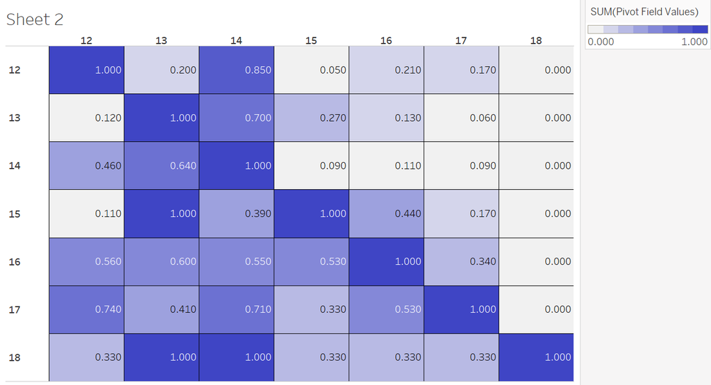

Correlation plot for screenID, with the column meaning the screen come first and row is screen come later

## 3.4 **Shrink front_end into form fitting date of back_end**

```r
front_end_fit_date <- front_end_ui %>%
  filter(date >= min(back_end$date), date <= max(back_end$date))
```

## 3.5 **Q4**

```r
front_end %>%
  filter(eventid == "x,13.02") %>%
  dim()
```

```
## [1] 1516    5
```

```r
user_eventid_13 <- front_end %>%
  group_by(id) %>%
  summarise(n_13 = sum(eventid == "x,13.02")) %>%
  filter(n_13 >= 1)

user_eventid_14 <- front_end %>%
  group_by(id) %>%
  summarise(n_14 = sum(eventid == "x,14.05")) %>%
  filter(n_14 >= 1)

user_eventid_13 %>%
  inner_join(user_eventid_14, by = "id") %>%
  dim()
```

```
## [1] 422   3
```

## 3.6 **Focus on number appear of eventid & predict which eventid is button LIEN KET NGAY**

```r
front_end_fit_date %>%
  group_by(id, screenid) %>%
  summarise(n = n()) %>%
  arrange(id)
```

```
## # A tibble: 9,003 x 3
## # Groups:   id [7,572]
##    id                  screenid     n
##    <chr>                  <dbl> <int>
##  1 BAACEAADIJBJJCDDIII       11     4
##  2 BAACFAHHCDFIHAAACCG       11    12
##  3 BAADIEBIJBGHCHJFBCF       11     6
##  4 BAADJFEGECHIJBEJJHA       11    16
##  5 BAAECHAHAHJIBFCIHH        11    12
##  6 BAAGJCFDAJEFGJHBHJA       11    12
##  7 BAAHGEDADFCGEIJEHID       11    14
##  8 BAAHJAEEFBHHCIDHCEG       11    12
##  9 BAAICJHADFBJGGAAGCE       11    18
## 10 BAAICJIFDGHDAGDCDHD       11     4
## # ... with 8,993 more rows
```

```r
id_screenid <- front_end %>%
  group_by(id, screenid) %>%
  summarise(n = n()) %>%
  arrange(id)

B_status_backend_1 <- B_status_backend %>%
  mutate(B_status = rep(1, nrow(B_status_backend)))

id_screenid %>%
  left_join(B_status_backend_1, by = "id") %>%
  mutate(B_status = ifelse(is.na(B_status), 0, 1))
```

```
## # A tibble: 16,265 x 5
## # Groups:   id [13,369]
##    id                  screenid     n B_num B_status
##    <chr>                  <dbl> <int> <int>    <dbl>
##  1 BAAAFACIBHCHHCCCAFH       11     4    NA        0
##  2 BAAAFFHHEDJFEAAFG         11    16    NA        0
##  3 BAABEBCJFBFDAGCHFAA       11     4    NA        0
##  4 BAACEAADIJBJJCDDIII       11     4    NA        0
##  5 BAACFAHHCDFIHAAACCG       11    12    NA        0
##  6 BAADFFICBCEGGCBBAD        11    36    NA        0
##  7 BAADIEBIJBGHCHJFBCF       11     6    NA        0
##  8 BAADJFEGECHIJBEJJHA       11    16    NA        0
##  9 BAAECHAHAHJIBFCIHH        11    12    NA        0
## 10 BAAFAAGJIFGCDABGGDD       11    16    NA        0
## # ... with 16,255 more rows
```

```r
front_end %>%
  group_by(id) %>%
  arrange(date) %>%
  slice(n()) %>%
  ungroup() %>%
  count(eventid, sort = TRUE)
```

```
## # A tibble: 21 x 2
##    eventid      n
##    <chr>    <int>
##  1 x,11.xy1  8580
##  2 x,11.xy8  2330
##  3 x,11.xy0  1377
##  4 x,11.xy3   323
##  5 x,13.04    307
##  6 x,11.xy5   113
##  7 x,11.xy7    90
##  8 x,14.05     54
##  9 x,14.02     53
## 10 x,15.06     44
## # ... with 11 more rows
```

# 4 **Analysis on userid**

## 4.1 **With 10 userid**

### 4.1.1 **For all userid**

```r
back_end_list_user <- back_end %>%
  select(id) %>%
  unique()

top100_user_action <- front_end_ui %>%
  group_by(id) %>%
  summarise(n = n()) %>%
  arrange(desc(n)) %>%
  slice(1:1000)

top1000_user_action <- front_end_ui %>%
  group_by(id) %>%
  summarise(n = n()) %>%
  arrange(desc(n)) %>%
  slice(1:1000)

front_end_ui %>%
  group_by(id, type) %>%
  summarise(n = n()) %>%
  arrange(desc(n)) %>%
  ungroup() %>%
  slice(1:100) %>%
  count(type)
```

```
## # A tibble: 2 x 2
##   type      n
##   <chr> <int>
## 1 new      85
## 2 old      15
```

```r
front_end_ui %>%
  group_by(id, screenid, type) %>%
  summarise(n = n()) %>%
  ungroup() %>%
  group_by(id) %>%
  mutate(n_overall = sum(n)) %>%
  arrange(desc(n_overall), desc(n))
```

```
## # A tibble: 16,265 x 5
## # Groups:   id [13,369]
##    id                  screenid type      n n_overall
##    <chr>                  <dbl> <chr> <int>     <int>
##  1 FFDBDJFJGCIJHBBACIA       11 new     128       366
##  2 FFDBDJFJGCIJHBBACIA       14 new     120       366
##  3 FFDBDJFJGCIJHBBACIA       12 new      76       366
##  4 FFDBDJFJGCIJHBBACIA       16 new      28       366
##  5 FFDBDJFJGCIJHBBACIA       17 new      14       366
##  6 CGBEACIHDDDHJFAAGCH       11 new     218       314
##  7 CGBEACIHDDDHJFAAGCH       14 new      58       314
##  8 CGBEACIHDDDHJFAAGCH       12 new      38       314
##  9 BIJIAAGEEGBFDHBHDE        11 new     116       280
## 10 BIJIAAGEEGBFDHBHDE        14 new     112       280
## # ... with 16,255 more rows
```

```r
top1000_user_action %>%
  inner_join(B_status_backend, by = "id")
```

```
## # A tibble: 93 x 3
##    id                      n B_num
##    <chr>               <int> <int>
##  1 BFHEHIDBJEJDABIAFBE   210     1
##  2 BJCBJIAIJBEHDGBEJJB   184     2
##  3 GJGCIIGCCDBGBFDBBDB   170     1
##  4 DCJIFJBCGFABGIACBJC   166     1
##  5 HDADFGAAADCACECHIII   154     4
##  6 GBJAJIBJGJGAHBIDCCI   138     1
##  7 JIABHGCAEAIJJGIEBCI   124     1
##  8 BHDHIJIIDJICBJCADHD   120     1
##  9 ICBHCCIGBDCFEBGHIBA   106     1
## 10 GIDCDJAEJFAHDEGCBDI   104     1
## # ... with 83 more rows
```

```r
front_end_ui %>%
  inner_join(back_end_list_user, by = "id") %>%
  group_by(id, screenid) %>%
  summarise(n = n()) %>%
  ungroup() %>%
  group_by(id) %>%
  mutate(n_overall = sum(n)) %>%
  arrange(desc(n_overall), desc(n))
```

```
## # A tibble: 3,891 x 4
## # Groups:   id [2,815]
##    id                  screenid     n n_overall
##    <chr>                  <dbl> <int>     <int>
##  1 CEGCEIGEIADAICDEJJF       14   112       256
##  2 CEGCEIGEIADAICDEJJF       11   102       256
##  3 CEGCEIGEIADAICDEJJF       16    22       256
##  4 CEGCEIGEIADAICDEJJF       12    12       256
##  5 CEGCEIGEIADAICDEJJF       13     8       256
##  6 HBGHADIFGJJHFADHCJF       11   124       226
##  7 HBGHADIFGJJHFADHCJF       14    64       226
##  8 HBGHADIFGJJHFADHCJF       12    22       226
##  9 HBGHADIFGJJHFADHCJF       13     8       226
## 10 HBGHADIFGJJHFADHCJF       16     8       226
## # ... with 3,881 more rows
```

### 4.1.2 **For new userid**

```r
front_end_ui %>%
  filter(type == "new") %>%
  group_by(id) %>%
  summarise(n = n()) %>%
  ungroup() %>%
  group_by(id) %>%
  mutate(n_overall = sum(n)) %>%
  arrange(desc(n_overall), desc(n))
```

```
## # A tibble: 1,279 x 3
## # Groups:   id [1,279]
##    id                      n n_overall
##    <chr>               <int>     <int>
##  1 FFDBDJFJGCIJHBBACIA   366       366
##  2 CGBEACIHDDDHJFAAGCH   314       314
##  3 BIJIAAGEEGBFDHBHDE    280       280
##  4 CEGCEIGEIADAICDEJJF   256       256
##  5 BDFEIDJFEAEJIHGEJCI   248       248
##  6 IIIAGFIHCIDEHGJEFCF   230       230
##  7 HBGHADIFGJJHFADHCJF   226       226
##  8 JDAIIHIFIJGCBGEGBDF   222       222
##  9 BFHEHIDBJEJDABIAFBE   210       210
## 10 IBHDAJGJIFIBHEHIJAH   208       208
## # ... with 1,269 more rows
```

### 4.1.3 **For old userid**

```r
front_end_ui %>%
  filter(type == "old") %>%
  group_by(id) %>%
  summarise(n = n()) %>%
  ungroup() %>%
  group_by(id) %>%
  mutate(n_overall = sum(n)) %>%
  arrange(desc(n_overall), desc(n))
```

```
## # A tibble: 12,090 x 3
## # Groups:   id [12,090]
##    id                      n n_overall
##    <chr>               <int>     <int>
##  1 DEBGAGAEJGEFGIIFCGH   222       222
##  2 DGHFFDIEJGCCCEDCFFD   206       206
##  3 JDGDAFJCDBIIJFJHABF   196       196
##  4 HDADFGAAADCACECHIII   154       154
##  5 IHFIAGHEHDIIAHJCAIB   150       150
##  6 GEIACGEHEDBJIAEFIED   140       140
##  7 CEDJIDFCJCGABBHHFIF   134       134
##  8 BCDCIEDFJEDIAJACHHF   128       128
##  9 IEAGGEAJBBBDHAHHEGE   128       128
## 10 BFBDEJCJAACHIFFDGHD   124       124
## # ... with 12,080 more rows
```

# 5 **Analysis on time-using by each user**

## 5.1 **Average time of each user**

- First, I make a data frame called `time_diff` to contain the different second between 2 event of 1 user. And I consider 2 event gap more than 1 hours together. I consider 2 these events is seperated and don’t count the time between them.
- The average time of each user using **UI** is **276 seconds**

```r
# second_diff <- front_end_ui %>%
#   group_by(id) %>%
#   summarise(date_diff = as.numeric(difftime(
#     strptime(max(date), format="%Y-%m-%d %H:%M:%S"),
#                            strptime(min(date), format="%Y-%m-%d %H:%M:%S"),
#                            units = "secs"))) %>%
#   filter(date_diff <= 3600) %>%
#   ungroup()

# second_diff %>%
#   summarise(avg = sum(date_diff)/n())

time_diff <- front_end %>%
  arrange(date) %>%
  group_by(id) %>%
  mutate(next_date = lead(date),
         time_diff = as.numeric(difftime(
    strptime(next_date, format="%Y-%m-%d %H:%M:%S"),
                           strptime(date, format="%Y-%m-%d %H:%M:%S"),
                           units = "secs"))) %>%
  filter(time_diff <= 3600) %>%
  ungroup()

time_diff %>%
  summarise(avg = sum(time_diff)/13369) %>%
  gt::gt()
```

| avg |
| --- |
| 275.7263 |

## 5.2 **Average time on each UI**

`time_userid` containing the total time using **UI** of each user.

```r
time_userid <- time_diff %>%
  select(id, time_diff) %>%
  group_by(id) %>%
  summarise(time = sum(time_diff))

time_userid %>%
  inner_join(user_type, by = "id") %>%
  group_by(type) %>%
  summarize(avg_time = sum(time)/n()) %>%
  gt::gt()
```

| type | avg_time |
| --- | --- |
| new | 702.6529 |
| old | 230.5618 |

## 5.3 **Average time of users have B status and users have no B status**

```r
time_userid %>%
  inner_join(back_end_list_user, by = "id") %>%
  left_join(B_status_backend, by = "id") %>%
  mutate(B_num = ifelse(is.na(B_num), 0, 1)) %>%
  group_by(B_num) %>%
  summarise(avg_time = sum(time)/n()) %>%
  gt::gt()
```

| B_num | avg_time |
| --- | --- |
| 0 | 565.8784 |
| 1 | 624.1494 |

## 5.4 **Find userid do not have B status but using UI over average time of people who not have B status**

### 5.4.1 **Get userid**

```r
front_end_user_id <- front_end %>%
  select(id) %>%
  unique()

time_userid %>%
  filter(time >= 566) %>%
  inner_join(user_retry, by = "id") %>%
  left_join(B_status_backend, by = "id") %>%
  inner_join(front_end_user_id, by = "id") %>%
  inner_join(user_type, by = "id") %>%
  filter(is.na(B_num)) %>%
  arrange(desc(time))
```

```
## # A tibble: 418 x 4
##    id                   time B_num type
##    <chr>               <dbl> <int> <chr>
##  1 IHFIAGHEHDIIAHJCAIB  9695    NA old
##  2 DEBGAGAEJGEFGIIFCGH  8963    NA old
##  3 JECDCBIHIIHIDBIHCCF  8465    NA old
##  4 CEDJIDFCJCGABBHHFIF  8429    NA old
##  5 FHCFBDIBHDJBCDDBDCA  8023    NA new
##  6 CEGHGJADGCAFEEIGCHG  7039    NA old
##  7 HBGHADIFGJJHFADHCJF  6843    NA new
##  8 CEFGEEGCFJEBEIDGEH   6771    NA old
##  9 GEIACGEHEDBJIAEFIED  6726    NA old
## 10 CGCDIBHIDJAGIDCHEHA  6587    NA old
## # ... with 408 more rows
```

### 5.4.2 **Count new and old**

```r
time_userid %>%
  filter(time >= 566) %>%
  inner_join(user_retry, by = "id") %>%
  left_join(B_status_backend, by = "id") %>%
  inner_join(front_end_user_id, by = "id") %>%
  inner_join(user_type, by = "id") %>%
  filter(is.na(B_num)) %>%
  count(type) %>%
  gt::gt()
```

| type | n |
| --- | --- |
| new | 99 |
| old | 319 |

## 5.5 **Investigate of some userid**

```r
front_end_ui %>%
  filter(id == "IHFIAGHEHDIIAHJCAIB") %>%
  count(eventid, sort = TRUE)
```

```
## # A tibble: 6 x 2
##   eventid      n
##   <chr>    <int>
## 1 x,11.xy0    30
## 2 x,11.xy3    28
## 3 x,11.xy5    28
## 4 x,11.xy7    28
## 5 x,11.xy8    26
## 6 x,11.xy1    10
```